# Self-Driving Car Engineer Nanodegree

## Project: Build a Traffic Sign Recognition Classifier

The goals / steps of this project are the following:

- Load the data set
- Explore, summarize and visualize the data set
- Design, train and test a model architecture
- Use the model to make predictions on new images
- Analyze the softmax probabilities of the new images
- Summarize the results with a written report

## Step 0: Load The Data

```python
# Load pickled data
import numpy as np
import os
import pickle

# Load in the training, validation and testing sets
sign_folder = 'traffic-signs-data'
training_file = os.path.join(sign_folder, 'train.p')
validation_file = os.path.join(sign_folder, 'valid.p')
testing_file = os.path.join(sign_folder, 'test.p')

with open(training_file, mode='rb') as f:
    train = pickle.load(f)
with open(validation_file, mode='rb') as f:
    valid = pickle.load(f)
with open(testing_file, mode='rb') as f:
    test = pickle.load(f)

X_train, y_train = train['features'], train['labels']
X_valid, y_valid = valid['features'], valid['labels']
X_test, y_test = test['features'], test['labels']

# Ensure that the features and the labels are the same
# size for each set of data
assert(len(X_train) == len(y_train))
assert(len(X_valid) == len(y_valid))
assert(len(X_test) == len(y_test))
```

## Step 1: Dataset Summary & Exploration

The code below will display the basic set up of the traffic sign sets.

### Provide a Basic Summary of the Data Set

```python
# Determine the number of examples in the training,
# validation and testing sets
n_train = len(X_train)
n_validation = len(X_valid)
n_test = len(X_test)

# Determine the shape of the images and the number of
# output classes associated with the dataset
image_shape = (len(X_train[0]), len(X_train[1]))
n_classes = np.max(train['labels']) + 1

# Display the collected information from the image sets
print("Number of training examples =", n_train)
print("Number of validation examples =", n_validation)
print("Number of testing examples =", n_test)
print("Image data shape =", image_shape)
print("Number of classes =", n_classes)
```

```
Number of training examples = 34799
Number of validation examples = 4410
Number of testing examples = 12630
Image data shape = (32, 32)
Number of classes = 43
```

### Exploratory visualization of the dataset

Several items from the data set are displayed in plots and figures below. First a random selection of 9 images are displayed from the training set. After that the distribution of sign types for the training, validation and test sets is plotted to show that there is an unequal distribution of sign types in the sets.

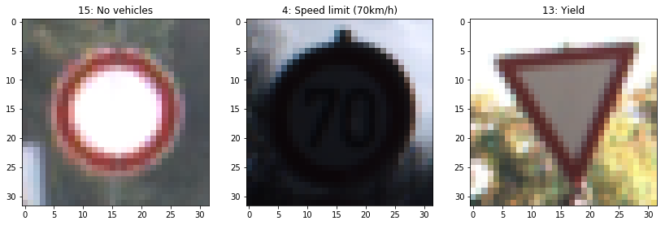

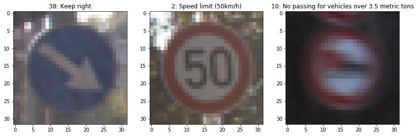

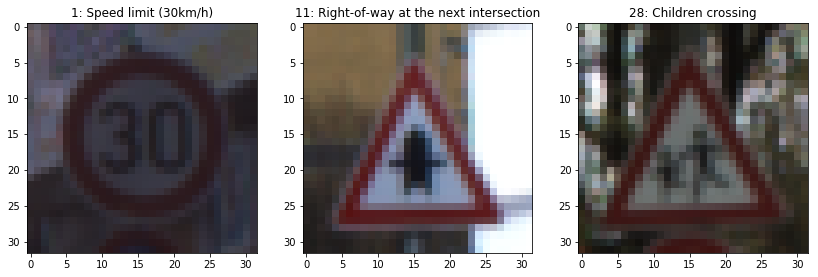

```python
import collections
import csv
import cv2
import matplotlib.pyplot as plt
import matplotlib.image as mpimg
import random
# Visualizations will be shown in the notebook.
%matplotlib inline

# The code below will randomly pull and display row*col images
# from the training set
col = 3
row = 3

for i in range(row):
    index = []
    image = []
    label = []

    # Each row will be a single figure using subplots to
    # fill in the columns
    plt.figure(figsize=(14, 10))
    for j in range(col):
        index.append(random.randint(0, n_train))
        image.append(X_train[index[j]].squeeze())

        # Pull the sign name from the included csv file
        # so it can be added to the title of each image
        with open('signnames.csv') as csvfile:
            reader = csv.DictReader(csvfile)
            for x in reader:
                if x['ClassId'] == str(y_train[index[j]]):
                    label.append(str(y_train[index[j]]) + \
                                 ": " + x['SignName'])

        plt.subplot(1, col, j+1)
        plt.title(label[j])
        plt.imshow(image[j])
```

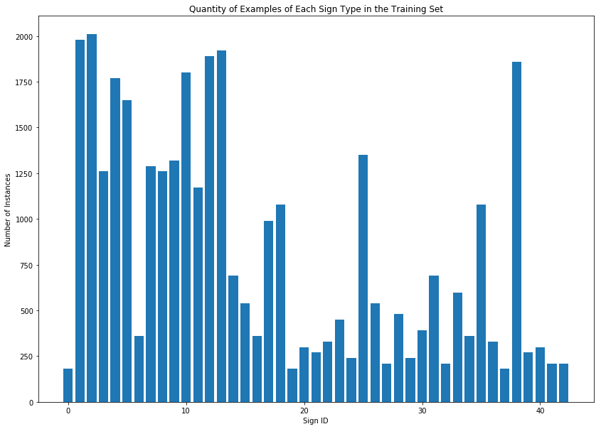

```python
# Determine distribution of sign examples in the training set
instances = collections.Counter(y_train)

plt.figure(figsize=[14, 10])
plt.bar(instances.keys(), instances.values())
plt.xlabel('Sign ID')
plt.ylabel('Number of Instances')
plt.title('Quantity of Examples of Each Sign Type in the Training Set')
plt.show()
```

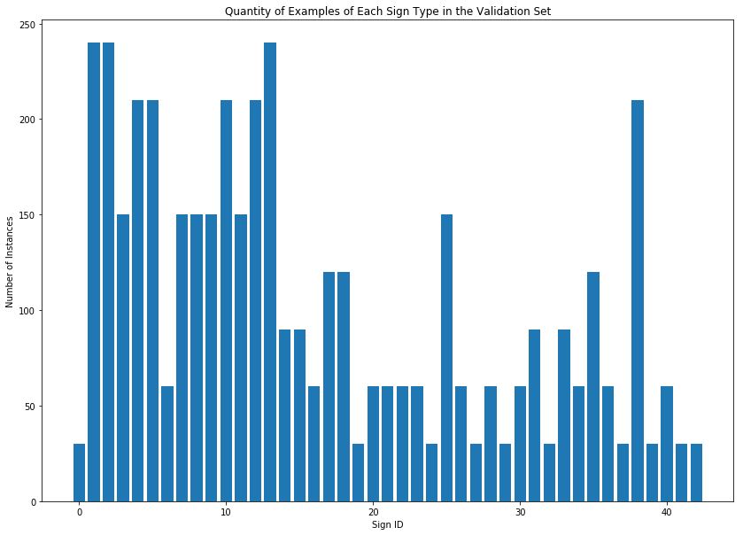

```python
# Determine distribution of sign examples in the validation set
instances = collections.Counter(y_valid)

plt.figure(figsize=[14, 10])
plt.bar(instances.keys(), instances.values())
plt.xlabel('Sign ID')
plt.ylabel('Number of Instances')
plt.title('Quantity of Examples of Each Sign Type in the Validation Set')
plt.show()
```

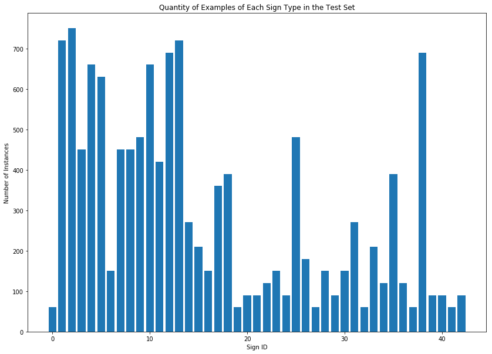

```python
# Determine distribution of sign examples in the test set
instances = collections.Counter(y_test)

plt.figure(figsize=[14, 10])
plt.bar(instances.keys(), instances.values())
plt.xlabel('Sign ID')
plt.ylabel('Number of Instances')
plt.title('Quantity of Examples of Each Sign Type in the Test Set')
plt.show()
```

## Step 2: Design and Test a Model Architecture

### Pre-process the Data Set (normalization, grayscale, etc.)

The data set is normalized and a grayscale version and HSV version is attached to each image (I changed the depth from 3, RGB, to 7 in this manner). This allows the CNN to have additional points of information to learn from.

```python
import random

def preprocess_data_set(data_set, y_data, extend=False):
    """This function will take the input data sets and prepare them for the
    model by adding a grayscale version and HSV version to the depth of the
    original set. The original data set will have an assumed depth of 3 (RGB)
    and the returned dataset will have a depth of 7.

    The function will also extend the data set with translated, rotated and
    zoomed copies of the original dataset if desired.

    Parameters
    ==========

    data_set: list like
        This is the collection of original images that are being processed.
        It is assumed that these images are rgb
    y_data: list like
        This is the collection of labels associated with the data set
    extend: Boolean
        This will let the function know whether or not to extend the data
        set with translated, rotated and zoomed versions of the images

    Returns
    =======

    result: array
        This is the array of the processed images
    y_data: list like
        This is the collection of labels associated with the result array
    """

    # If the extend flag is True, concatenate translated, rotated and
    # zoomed image sets to the original data set and concatenate the y_data
    # set to itself to compensate
    if extend:
        # Retrieve the shape information of the input data set
        rows, cols, depth = data_set[0].shape

        # Create a translated image set
        translate = []
        movement = [-2, -1, 1, 2]
        for i in data_set:
            x_move = random.choice(movement)
            y_move = random.choice(movement)
            rot_matrix = np.float32([[1, 0, x_move], [0, 1, y_move]])
            translate.append(cv2.warpAffine(i, rot_matrix, (cols, rows)))

        # Create a rotated image set
        rotate = []
        movement = [-15, -10, -5, 5, 10, 15]
        for i in data_set:
            angle = random.choice(movement)
            rot_matrix = cv2.getRotationMatrix2D((cols/2, rows/2), angle, 1)
            rotate.append(cv2.warpAffine(i, rot_matrix, (cols, rows)))

        # Create a scaled image set
        zoom = []
        sizes = [0.9, 1.1]
        for i in data_set:
            zoomfactor = random.choice(sizes)
            rot_matrix = cv2.getRotationMatrix2D((cols/2, rows/2), 0, zoomfactor)
            zoom.append(cv2.warpAffine(i, rot_matrix, (cols, rows)))

        # Concatenate the translated, rotated and scaleded images with the
        # original set
        data_set = np.concatenate((data_set, translate, rotate, zoom))
        y_data = np.concatenate((y_data, y_data, y_data, y_data))

    # Create and normalize a grayscale version of the dataset
    gray = []
    for i in data_set:
        gray.append(cv2.cvtColor(i, cv2.COLOR_RGB2GRAY))
        gray[-1] = gray[-1].astype(float)
        for x in gray[-1]:
            for y in range(len(x)):
                x[y] = (x[y] - 128)/128


    # Create and normalize an HSV version of the dataset
    hsv = []
    for i in data_set:
        hsv.append(cv2.cvtColor(i, cv2.COLOR_RGB2HSV))
        hsv[-1] = hsv[-1].astype(float)
        for x in hsv[-1]:
            for y in range(len(x)):
                x[y][0] = (x[y][0] - 128)/128
                x[y][1] = (x[y][1] - 128)/128
                x[y][2] = (x[y][2] - 128)/128

    # Normalize the original RGB data_set
    norm = []
    for i in data_set:
        norm.append(np.copy(i))
        norm[-1] = norm[-1].astype(float)
        for x in norm[-1]:
            for y in range(len(x)):
                x[y][0] = (x[y][0] - 128)/128
                x[y][1] = (x[y][1] - 128)/128
                x[y][2] = (x[y][2] - 128)/128

    # Append the gray and hsv images to the result image
    # set (this will change the depth of the image from 3 to 7)
    result = np.zeros([data_set.shape[0], data_set.shape[1],
                       data_set.shape[2], 7])
    for i in range(len(result)):
        for x in range(len(result[0])):
            for y in range(len(result[0][0])):
                result[i][x][y] = np.append(norm[i][x][y],
                                            [gray[i][x][0],
                                             hsv[i][x][y][0],
                                             hsv[i][x][y][1],
                                             hsv[i][x][y][2]])


    return result, y_data


# Pre-process the training, validation and test sets. Saving and loading used
# to save time when using the processed sets later. The data sets were too
# large for pickle to handle and so numpy is used for the saving and loading operations.
preprocess_images_directory = 'preprocess-traffic-signs-data'
if not os.path.exists(preprocess_images_directory):
    os.makedirs(preprocess_images_directory)
    X_train, y_train = preprocess_data_set(X_train, y_train, extend=True)
    X_valid, y_valid = preprocess_data_set(X_valid, y_valid)
    X_test, y_test = preprocess_data_set(X_test, y_test)
    with open(os.path.join(preprocess_images_directory, 'train.npz'), 'wb') as train_file:
        np.savez(train_file, X_train, y_train, allow_pickle=False)
    with open(os.path.join(preprocess_images_directory, 'valid.npz'), 'wb') as valid_file:
        np.savez(valid_file, X_valid, y_valid, allow_pickle=False)
    with open(os.path.join(preprocess_images_directory, 'test.npz'), 'wb') as test_file:
        np.savez(test_file, X_test, y_test, allow_pickle=False)
else:
    with open(os.path.join(preprocess_images_directory, 'train.npz'), 'rb') as train_file:
        data = np.load(train_file, allow_pickle=False)
        X_train = data['arr_0']
        y_train = data['arr_1']
    with open(os.path.join(preprocess_images_directory, 'valid.npz'), 'rb') as valid_file:
        data = np.load(valid_file, allow_pickle=False)
        X_valid = data['arr_0']
        y_valid = data['arr_1']
    with open(os.path.join(preprocess_images_directory, 'test.npz'), 'rb') as test_file:
        data = np.load(test_file, allow_pickle=False)
        X_test = data['arr_0']
        y_test = data['arr_1']
```

### Model Architecture

The architecture that is selected is a modified LeNet CNN. The layer structure is preserved but the size of each layer is altered to improve performance.

```python
import tensorflow as tf
from tensorflow.contrib.layers import flatten

def CovNet(x):
    """This function defines the convolutional network architecture
    that I used for this project. The overall architecture is that
    of the LeNet implementation with the sizes of the layers altered.

    Parameters
    ==========

    x: TensorFlow tensor (?, 32, 32, 7)
        This is the input tensor to the convolutional network

    Returns
    =======

    logits: TensorFlox Tensor (?, 43)
        This is the output of the convolutional network
    """

    # Arguments used for tf.truncated_normal, randomly defines variables
    # for the weights and biases for each layer
    mu = 0
    sigma = 0.1


    # Layer 1: Convolutional. Input = 32x32x7. Output = 28x28x20.
    l1weights = tf.Variable(tf.truncated_normal([5, 5, 7, 20], mu, sigma))
    l1bias = tf.Variable(tf.zeros(20))
    layer1 = tf.nn.conv2d(x, l1weights, [1, 1, 1, 1], 'VALID')
    layer1 = tf.nn.bias_add(layer1, l1bias)

    # Layer 1 Activation Function: RELU
    layer1 = tf.nn.relu(layer1)

    # Layer 1 Pooling: Input = 28x28x20. Output = 14x14x20.
    pool1 = tf.nn.max_pool(layer1, [1, 2, 2, 1], [1, 2, 2, 1], 'VALID')


    # Layer 2: Convolutional. Input = 14x14x20 Output = 10x10x42.
    l2weights = tf.Variable(tf.truncated_normal([5, 5, 20, 42], mu, sigma))
    l2bias = tf.Variable(tf.zeros(42))
    layer2 = tf.nn.conv2d(pool1, l2weights, [1, 1, 1, 1], 'VALID')
    layer2 = tf.nn.bias_add(layer2, l2bias)

    # Layer 2 Activation Function: RELU
    layer2 = tf.nn.relu(layer2)

    # Layer 2 Pooling: Input = 10x10x42. Output = 5x5x42.
    pool2 = tf.nn.max_pool(layer2, [1, 2, 2, 1], [1, 2, 2, 1], 'VALID')


    # Flatten. Input = 5x5x42. Output = 1050.
    flat = flatten(pool2)

    # Layer 3: Fully Connected. Input = 1050. Output = 500.
    l3weights = tf.Variable(tf.truncated_normal([1050, 500], mu, sigma))
    l3bias = tf.Variable(tf.zeros(500))
    layer3 = tf.matmul(flat, l3weights) + l3bias

    # Layer 3 Activation Function: RELU
    layer3 = tf.nn.relu(layer3)


    # Layer 4: Fully Connected. Input = 500. Output = 120.
    l4weights = tf.Variable(tf.truncated_normal([500, 120], mu, sigma))
    l4bias = tf.Variable(tf.zeros(120))
    layer4 = tf.matmul(layer3, l4weights) + l4bias

    # Layer 4 Activation Function: RELU
    layer4 = tf.nn.relu(layer4)


    # Layer 5: Fully Connected. Input = 120. Output = 43.
    l5weights = tf.Variable(tf.truncated_normal([120, 43], mu, sigma))
    l5bias = tf.Variable(tf.zeros(43))
    logits = tf.matmul(layer4, l5weights) + l5bias

    return logits
```

### Set up labels and features

```python
# Create the features and labels tensors. The labels tensor
# needs to be converted to a one-hot format
x = tf.placeholder(tf.float32, (None, 32, 32, 7))
y = tf.placeholder(tf.int32, (None))
one_hot_y = tf.one_hot(y, 43)
```

### Training Pipeline

```python
# Set up variables needed for the training and the convolutional network model
rate = 0.001
logits = CovNet(x)

# Set up the loss function for the training
cross_entropy = tf.nn.softmax_cross_entropy_with_logits_v2(labels=one_hot_y, logits=logits)
loss_operation = tf.reduce_mean(cross_entropy)

# Set up the optimizer for the training
optimizer = tf.train.AdamOptimizer(learning_rate = rate)
training_operation = optimizer.minimize(loss_operation)
```

### Model Evaluation

```python
# Set up the model evaluation parameters
EPOCHS = 10
BATCH_SIZE = 50

# Set up tensors to determine the percentage of correct classifications
correct_prediction = tf.equal(tf.argmax(logits, 1), tf.argmax(one_hot_y, 1))
accuracy_operation = tf.reduce_mean(tf.cast(correct_prediction, tf.float32))


def evaluate(X_data, y_data):
    """This function will determine the averaged accuracy of the model for
    input features and labels.

    Parameters
    ==========

    X_data: TensorFlow tensor (?, 32, 32, 7)
        This is the input features for which the model will attempt to classify
    y_data: TensorFlow tensor(?, 43)
        This is the one-hot tensor of labels associated with the input features

    Returns
    =======

    Average Accuracy: float
        The function will return the overall average accuracy of the model
    """

    num_examples = len(X_data)

    # Sum up the accuracy for each example in the feature and label sets
    total_accuracy = 0
    sess = tf.get_default_session()
    for offset in range(0, num_examples, BATCH_SIZE):
        batch_x, batch_y = X_data[offset:offset+BATCH_SIZE], y_data[offset:offset+BATCH_SIZE]
        accuracy = sess.run(accuracy_operation, feed_dict={x: batch_x, y: batch_y})
        total_accuracy += (accuracy * len(batch_x))

    # Return the average accuracy
    return total_accuracy / num_examples
```

### Train the Model

```python
from sklearn.utils import shuffle

# Set up the ability to save the model after it is trained
saver = tf.train.Saver()

with tf.Session() as sess:
    sess.run(tf.global_variables_initializer())
    num_examples = len(X_train)

    # Run the training operation for the convolutional neural network
    print("Training...")
    print()
    for i in range(EPOCHS):
        # Shuffle the data each epoch to reduce the effect of the order
        # of the examples
        X_train, y_train = shuffle(X_train, y_train)

        # Run the training operation on the training set splitting up
        # according to batch size
        for offset in range(0, num_examples, BATCH_SIZE):
            end = offset + BATCH_SIZE
            batch_x, batch_y = X_train[offset:end], y_train[offset:end]
            sess.run(training_operation, feed_dict={x: batch_x, y: batch_y})

        # Determine and print the accuracy of the training set and validation
        # set each epoch
        training_accuracy = evaluate(X_train, y_train)
        validation_accuracy = evaluate(X_valid, y_valid)
        print("EPOCH {} ...".format(i+1))
        print("Training Accuracy = {:.3f}".format(training_accuracy))
        print("Validation Accuracy = {:.3f}".format(validation_accuracy))
        print()

    # When the number of epochs has been reached, save the model
    saver.save(sess, './covnet')
    print("Model saved")
```

```
Training...

EPOCH 1 ...
Training Accuracy = 0.975
Validation Accuracy = 0.907

EPOCH 2 ...
Training Accuracy = 0.975
Validation Accuracy = 0.910

EPOCH 3 ...
Training Accuracy = 0.986
Validation Accuracy = 0.922

EPOCH 4 ...
Training Accuracy = 0.994
Validation Accuracy = 0.940

EPOCH 5 ...
Training Accuracy = 0.992
Validation Accuracy = 0.939

EPOCH 6 ...
Training Accuracy = 0.993
Validation Accuracy = 0.944

EPOCH 7 ...
Training Accuracy = 0.995
Validation Accuracy = 0.942

EPOCH 8 ...
Training Accuracy = 0.995
Validation Accuracy = 0.946

EPOCH 9 ...
Training Accuracy = 0.996
Validation Accuracy = 0.940

EPOCH 10 ...
Training Accuracy = 0.995
Validation Accuracy = 0.954

Model saved
```

### Precision and Recall

```
INFO:tensorflow:Restoring parameters from ./covnet
```

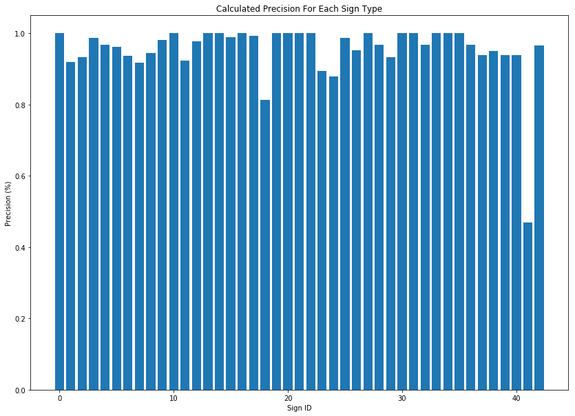

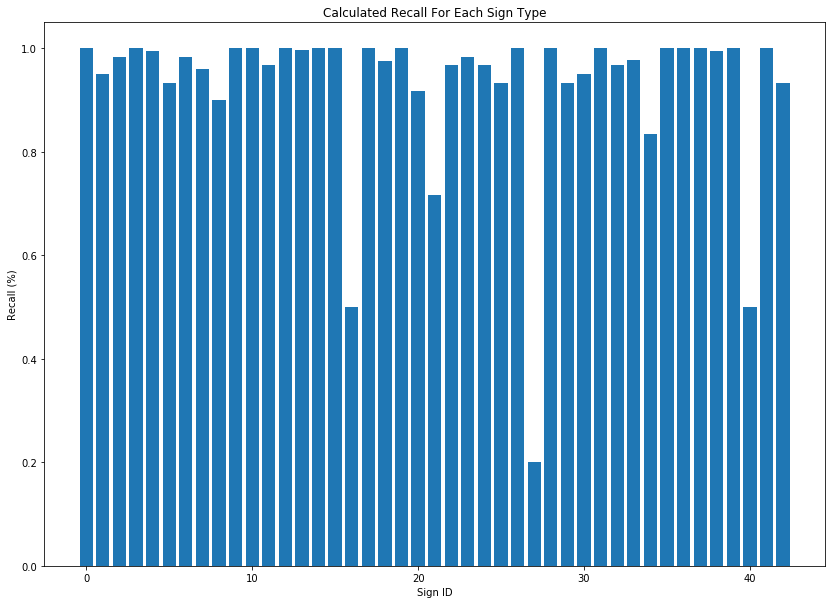

```python
# Set up arrays to tally correct predictions and false positives
correct = np.zeros((43))
false_positive = np.zeros((43))

# Run the model over the validation set and determine the number
# of correct predictions and false positives for each sign type
with tf.Session() as sess:
    saver.restore(sess, './covnet')
    for i in range(len(X_valid)):
        output = sess.run(logits, feed_dict={x: [X_valid[i]]})
        if np.argmax(output) == y_valid[i]:
            correct[np.argmax(output)] += 1
        else:
            false_positive[np.argmax(output)] += 1

# Set up the parameters that will be needed to calculate and plot
# the precision and recall
labels = np.arange(0, 43)
instances = collections.Counter(y_valid)

# Calculate the precision and recall
precision = [correct[i]/(correct[i]+false_positive[i]) for i in range(43)]
recall = [correct[i]/instances[i] for i in range(43)]

# Plot the precision and recall that was calculated for each sign type
plt.figure(figsize=[14, 10])
plt.bar(labels, precision)
plt.xlabel('Sign ID')
plt.ylabel('Precision (%)')
plt.title('Calculated Precision For Each Sign Type')
plt.show()

plt.figure(figsize=[14, 10])
plt.bar(labels, recall)
plt.xlabel('Sign ID')
plt.ylabel('Recall (%)')
plt.title('Calculated Recall For Each Sign Type')
plt.show()
```

### Evaluate Test Set

```python
with tf.Session() as sess:
    saver.restore(sess, './covnet')

    test_accuracy = evaluate(X_test, y_test)
    print("Test Accuracy = {:.3f}".format(test_accuracy))
```

```
INFO:tensorflow:Restoring parameters from ./covnet
Test Accuracy = 0.945
```

## Step 3: Test a Model on New Images

Five german traffic sign images were found online and are being used to test the model on a set of images separate from the provided image set. The images selected are simple to determine if the model can work on images apart from the ones provided.

### Load and Output the Images

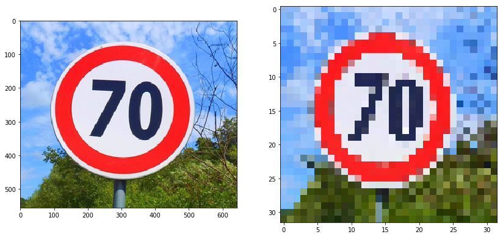

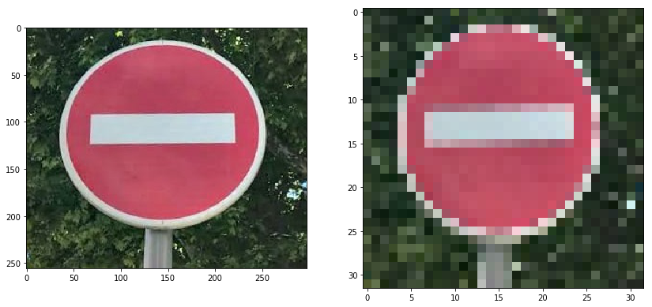

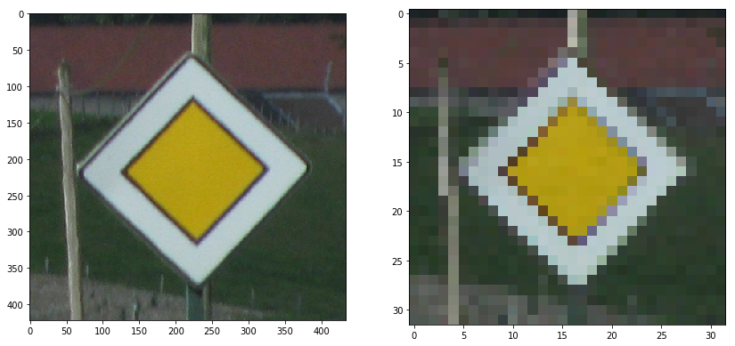

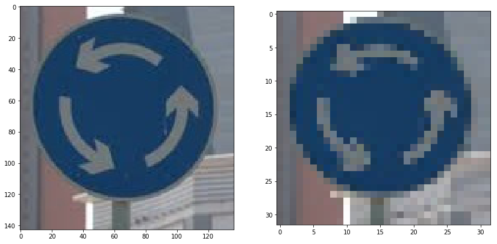

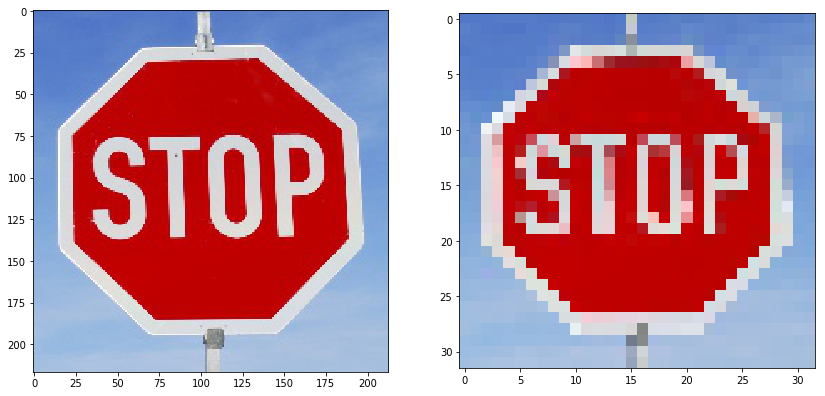

```python
import matplotlib
import matplotlib.image as mpimg

# Load all of the images in online-images folder
online_image_dir = 'online-images'
images = [os.path.join(online_image_dir, i) for i in os.listdir(online_image_dir)]

# Set up the list of correct classifications
correct_labels = [4, 17, 12, 40, 14]

# Load in the images, resize them to 32x32 pixels and send them through
# the neural network's preprocessor
images = [mpimg.imread(i) for i in images]
resized_images = np.array([cv2.resize(i, (32, 32)) for i in images])
processed_images, empty = preprocess_data_set(resized_images, [])

# Display the loaded images
for i in range(len(images)):
    plt.figure(figsize=(14, 10))
    plt.subplot(1, 2, 1)
    plt.imshow(images[i])
    plt.subplot(1, 2, 2)
    plt.imshow(resized_images[i])
    plt.show()
```

### Predict the Sign Type for Each Image

```python
# Run the model on the set of online images
with tf.Session() as sess:
    saver.restore(sess, './covnet')
    test_accuracy = sess.run(tf.nn.softmax(logits),
                             feed_dict={x: processed_images})

# Determine the models sign type prediction for each image
predictions = [np.argmax(i) for i in test_accuracy]

# Pull the sign name from the included csv file
# so it can be added to the title of each image
named_predictions = []
for i in predictions:
    with open('signnames.csv') as csvfile:
        reader = csv.DictReader(csvfile)
        for j in reader:
            if j['ClassId'] == str(i):
                named_predictions.append(str(i) + \
                             ": " + j['SignName'])

# Display the predictions
print("\nPredictions")
for i in named_predictions:
    print("Prediction -", i)
```

```
INFO:tensorflow:Restoring parameters from ./covnet

Predictions
Prediction - 1: Speed limit (30km/h)
Prediction - 17: No entry
Prediction - 12: Priority road
Prediction - 40: Roundabout mandatory
Prediction - 14: Stop
```

### Analyze Performance

```python
### Calculate the accuracy for the online images.
n = len(predictions)
correct = 0
for i in range(n):
    if correct_labels[i] == predictions[i]:
        correct += 1
performance = correct/n

# Display the calculated accuracy
print("Accuracy = %.2f" % (100*performance))
```

```
Accuracy = 80.00
```

### Output Top 5 Softmax Probabilities For Each Image Found on the Web

For each of the new images, print out the model's top 5 softmax probabilities to show the **certainty** of the model's predictions

```python
# Determine the top 5 probabilities for each image
with tf.Session() as sess:
    output = sess.run(tf.nn.top_k(tf.constant(test_accuracy), k=5))

# Load the sign names from the csv file and display the top
# 5 softmax probabilities
for i in range(n):
    with open('signnames.csv') as csvfile:
        reader = csv.DictReader(csvfile)
        for j in reader:
            if j['ClassId'] == str(correct_labels[i]):
                sign_type = j['SignName']
    print("Image: %d - %s" % (i, sign_type))
    print("\tPrediction : Certainty (%)")
    for j, k in zip(output.indices[i], output.values[i]):
        print("\t", j, ": ", k*100)
```

```
Image: 0 - Speed limit (70km/h)
	Prediction : Certainty (%)
	 1 :  84.06825661659241
	 4 :  15.931662917137146
	 0 :  7.823178407306841e-05
	 39 :  1.4335047038294135e-08
	 7 :  2.9657405004046566e-09
Image: 1 - No entry
	Prediction : Certainty (%)
	 17 :  100.0
	 0 :  0.0
	 1 :  0.0
	 2 :  0.0
	 3 :  0.0
Image: 2 - Priority road
	Prediction : Certainty (%)
	 12 :  100.0
	 0 :  0.0
	 1 :  0.0
	 2 :  0.0
	 3 :  0.0
Image: 3 - Roundabout mandatory
	Prediction : Certainty (%)
	 40 :  99.99988079071045
	 38 :  0.00011840955949082854
	 39 :  5.191105878488145e-09
	 1 :  2.8415290953542893e-10
	 12 :  2.6193850148799325e-12
Image: 4 - Stop
	Prediction : Certainty (%)
	 14 :  100.0
	 0 :  0.0
	 1 :  0.0
	 2 :  0.0
	 3 :  0.0
```